# Project 3 Data Science Skills

Umais Siddiqui,Neil Hwang, Michelle Mondy, Kalyanaraman Parthasarathy and Murali Kunissery

October 17, 2017

Rpubs link: http://rpubs.com/umais/Project3_Data607 |

```
        http://rpubs.com/neilhwang/group2

        http://rpubs.com/mkunissery/321374

        http://rpubs.com/mmondy/320996
```

GitHub link: https://github.com/umais/Data607-Project3

## Obejective

In this project our goal is to be able to answer the question

**“Which are the most valued data science skills?”**

## Approach

In order to find the answer to our question we have researched a couple of job searching websites and decided to use CyberCoders and Indeed website to scrape the skillsets required for Jobs that had a title of Data Scientist.We will be using the rvest and MySQL libraries. rvest will be used to scrape and parse the HTML data.

```r
library(devtools)
library(RMySQL)
library(arules)
```

```r
library(arulesViz)
library(ggplot2)
library(plyr)
```

## Database Schema

CREATE TABLE DataScienceJobs(

```
       JobId int auto_increment primary key,

       JobTitle nvarchar(255),

       JobLocation nvarchar(255),

       JobSalary nvarchar(255),

       Source nvarchar(255)
```

);

CREATE TABLE DataScienceSkills(

```
       SkillId int auto_increment primary key,

       JobId int,

       SkillName nvarchar(255)
```

);

## Data Collection

We seperated out the data collection part in in a R Script file called Project3.R

In that file we are scraping the data from CyberCoders and Indeed website for Jobs that have a title of data scientist and inserting it in to the tables created based on the above schema. Below is the link to that code.

https://github.com/umais/Data607-Project3/blob/master/Project3/Project3.R

## Retrieving Data from MySQL

We will be retrieving the data inserted in MYSQL from the scraping done from the R script file and performing some downstream analysis on the data.

```r
mydb = dbConnect(MySQL(), user='root', password='Welcome@1', dbname='project3', host='localhost')
#mydb = dbConnect(MySQL(), user='root', password='password', host= '127.0.0.1', port=3306)
#dbSendQuery(mydb, "CREATE DATABASE project3;")
#dbSendQuery(mydb, "USE project3")
  results = dbSendQuery(mydb, "SELECT j.JobTitle,j.JobLocation,s.SkillName FROM DataScienceJobs j INNER JOIN DataScienceSkills s ON j.JobId=s.JobId  ;")

  jobSkills=fetch(results, n=-1)

  head(jobSkills)
```

```
##           JobTitle         JobLocation           SkillName
## 1  Data Scientist       Sunnyvale, CA               Python
## 2  Data Scientist       Sunnyvale, CA               C/C++
## 3  Data Scientist       Sunnyvale, CA        Apache Spark
## 4  Data Scientist       Sunnyvale, CA               Kafka
## 5  Data Scientist       Sunnyvale, CA       ElasticSearch
## 6  Data Scientist   San Francisco, CA   Postgres/Redshift
```

## More Analysis

We can tell by the initial results from group by query that Python is the skill that is most valued.

```r
  rs = dbSendQuery(mydb, "SELECT SkillName,Count(1) as Total FROM DataScienceJobs j INNER JOIN DataScienceSkills s ON j.JobId=s.JobId GROUP BY SkillName Order By Total desc ;")

  df=fetch(rs, n=-1)



  head(df)
```

```
##            SkillName Total
## 1             Python   168
## 2  Machine Learning    122
## 3                 R     82
## 4      Data Science     56
## 5            Hadoop     55
## 6          Big Data     50
```

## Looking at Indeed Data

If we look at only Indeed data again we can see that Python , R and Machine Learning are among the top required skills.

```r
      rs = dbSendQuery(mydb, "SELECT SkillName,Source,Count(1) as Total FROM DataScienceJobs j INNER JOIN DataScienceSkills s ON j.JobId=s.JobId Where Source='Indeed' GROUP BY SkillName,Source Order By Total desc ;")

        IndeedDF=fetch(rs, n=-1)
        head(IndeedDF)
```

```
##            SkillName Source Total
## 1             Python Indeed    99
## 2                 R  Indeed    82
## 3  Machine Learning  Indeed    61
## 4      Data Science  Indeed    56
## 5            Hadoop  Indeed    55
## 6          Big Data  Indeed    50
```

## Looking at CyberCoders Data

Similarly in Cyber Coders data we see the same thing that Python,R,Machine Learning and Hadoop are among the top required skills for data scientist.

```r
    rs = dbSendQuery(mydb, "SELECT SkillName,Source,Count(1) as Total FROM DataScienceJobs j INNER JOIN DataScienceSkills s ON j.JobId=s.JobId Where Source='CyberCoders' GROUP BY SkillName,Source Order By Total desc ;")

        CyberCoderDF=fetch(rs, n=-1)
        head(CyberCoderDF)
```

```
##            SkillName      Source Total
## 1             Python CyberCoders    69
## 2  Machine Learning  CyberCoders    61
## 3                 R  CyberCoders    30
## 4            Hadoop  CyberCoders    21
## 5       Data Mining  CyberCoders    21
## 6      Data Science  CyberCoders    18
```

```r
  rs = dbSendQuery(mydb, "SELECT j.JobId,JobTitle,JobLocation,JobSalary,SkillName,Source FROM DataScienceJobs j INNER JOIN DataScienceSkills s ON j.JobId=s.JobId ;")

  AllJobs=fetch(rs, n=-1)

head(AllJobs)
```

```
##   JobId         JobTitle         JobLocation                 JobSalary
## 1     1  Data Scientist       Sunnyvale, CA   Full-time $150k - $200k
## 2     1  Data Scientist       Sunnyvale, CA   Full-time $150k - $200k
## 3     1  Data Scientist       Sunnyvale, CA   Full-time $150k - $200k
## 4     1  Data Scientist       Sunnyvale, CA   Full-time $150k - $200k
## 5     1  Data Scientist       Sunnyvale, CA   Full-time $150k - $200k
## 6     2  Data Scientist   San Francisco, CA    Full-time $90k - $130k
##             SkillName      Source
## 1              Python CyberCoders
## 2              C/C++  CyberCoders
## 3       Apache Spark  CyberCoders
## 4              Kafka  CyberCoders
## 5      ElasticSearch  CyberCoders
## 6  Postgres/Redshift  CyberCoders
```

## Association Analysis

To explore the data further, we perform an association analysis, which is one of the more popular unsupervised machine learning algorithms, using the package *arules*. To begin, we preoprocess the data to list the skills by specific jobs.

```r
df <- data.frame(matrix(ncol = 2, nrow = nrow(AllJobs)))
df[,1] <- factor(AllJobs[,"JobId"])
df[,2] <- factor(AllJobs[,"SkillName"])
temp <- df[,c(1,2)]
first_item <- ddply(temp, .(X1), function(x) x[1, ])
temp2 <- merge(x = temp, y = first_item, by = "X1", all.x = TRUE)
data <- temp2[duplicated(temp2$X1),]
data$X1 <- data$X2.y
data$X2.y <- NULL
names(data) <- c("X", "Y")
m <- as.matrix(data)
l <- lapply(1:nrow(m), FUN = function(i) (m[i, ]))
```

Now, we convert the list into transactions that *arules* can work with in forming aprior rules to identify the most common associations that tend to occur together among skills.

```r
transactions <- as(l, "transactions")
itemsets <- apriori(transactions, parameter = list(target = "frequent",
    supp=0.001, minlen = 2, maxlen=6))
```

```
## Apriori
##
## Parameter specification:
##  confidence minval smax arem  aval originalSupport maxtime support minlen
##          NA    0.1    1 none FALSE            TRUE       5   0.001      2
##  maxlen            target   ext
##       6 frequent itemsets FALSE
##
## Algorithmic control:
##  filter tree heap memopt load sort verbose
##     0.1 TRUE TRUE  FALSE TRUE    2    TRUE
##
## Absolute minimum support count: 1
##
## set item appearances ...[0 item(s)] done [0.00s].
## set transactions ...[238 item(s), 1380 transaction(s)] done [0.00s].
## sorting and recoding items ... [146 item(s)] done [0.00s].
## creating transaction tree ... done [0.00s].
## checking subsets of size 1 2 done [0.00s].
## writing ... [169 set(s)] done [0.00s].
## creating S4 object  ... done [0.00s].
```

This frequency plot confirms our findings earlier that among the most demanded skill of data scientists are python, machine learning, R, data mining, and hadoop.

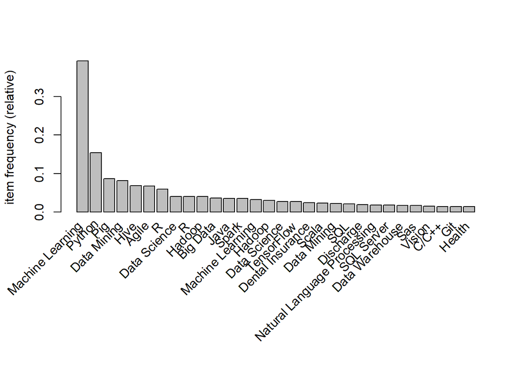

```r
#Top 30 most frequently occurring skills
itemFrequencyPlot(transactions, topN=30)
```

```r
quality(itemsets)$lift <- interestMeasure(itemsets, measure="lift", trans = transactions)

#Top 30 associations
inspect(head(sort(itemsets, by = "lift"), n=30))
```

```
##      items                                             support       lift
## [1]  { Data science (from industry) ,
##        Phenomenal written and oral communication } 0.001449275 230.000000
## [2]  { Data science (from industry) ,
##        Machine Learning Algorithms }               0.001449275 230.000000
## [3]  { Pricing Decisions ,
##        Pricing Engine }                            0.001449275 172.500000
## [4]  { Pricing Engine ,
##        Pricing Model }                             0.001449275 172.500000
## [5]  { Pricing Engine ,
##        Revenue Management }                        0.001449275 172.500000
## [6]  { Alternative Data ,
##        Quantitative Research }                     0.001449275  55.200000
## [7]  { SCADA ,
##        SQL }                                       0.001449275  47.586207
## [8]  { Alternative Data ,
##        Financial Services }                        0.001449275  46.000000
## [9]  { Bayesian Inference ,
##        Data Science }                              0.001449275  36.315789
## [10] { Data Science ,
##        Virtual Environments }                      0.001449275  36.315789
## [11] { Data Science ,
##        scikit.learn }                              0.001449275  36.315789
## [12] { Deep Learning ,
##        Natural Language Processing (NLP) }         0.001449275  35.844156
## [13] { Hadoop ,
##        numpy }                                     0.002898551  32.857143
## [14] { Hadoop ,
##        matplotlib }                                0.002898551  32.857143
## [15] { Hadoop ,
##        pandas }                                    0.002898551  21.904762
## [16] {  Azure ,
##        Agile }                                     0.001449275  14.838710
## [17] {  HBase ,
##        Hive }                                      0.001449275  14.680851
## [18] {  PostgresSQL ,
##        SQL Server }                                0.001449275  13.800000
## [19] {  AI ,
##        TensorFlow }                                0.001449275  12.105263
## [20] { Pricing Engine ,
##        SQL }                                       0.001449275  11.896552
## [21] {  Oracle ,
##        Pig }                                       0.007246377  10.454545
## [22] {  Perl ,
##        Hive }                                      0.001449275   9.787234
## [23] { Data Scientist ,
##        SQL }                                       0.001449275   9.517241
## [24] {  MATLAB ,
##        Discharge }                                 0.001449275   8.846154
## [25] {  Hive ,
##        Pig }                                       0.007971014   8.433333
## [26] {  Paid Time Off ,
##        Data Mining }                               0.007971014   7.133459
## [27] {  MySQL ,
##        Pig }                                       0.007246377   6.764706
## [28] { Data Scientist ,
##        Hadoop }                                    0.001449275   6.571429
## [29] { C/C++ ,
##       Python}                                      0.002173913   6.509434
## [30] { Kafka ,
##       Python}                                      0.002173913   6.509434
```

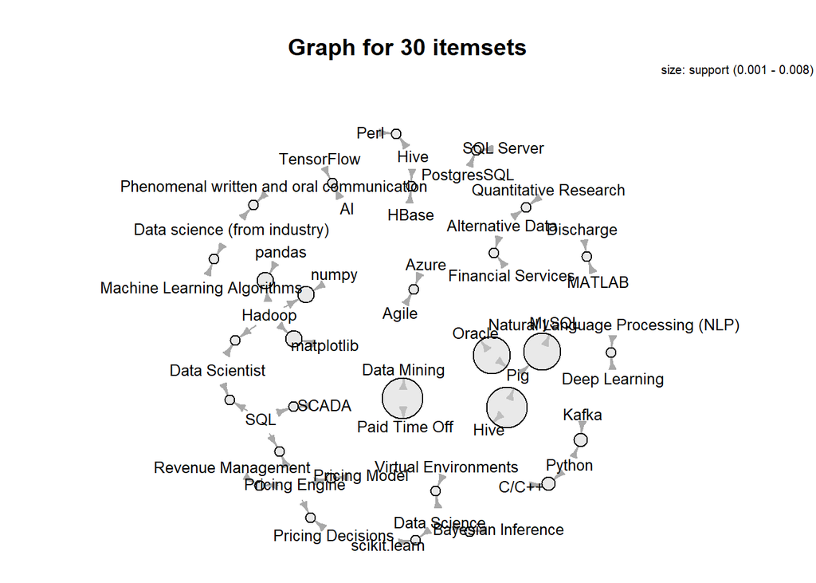

```r
#Visualization of top associations and skills
plot(head(sort(itemsets, by = "lift"), n=30), method = "graph", control=list(cex=.8))
```

## Conclusion

Based on the data collected from CyberCoders and Indeed we can see after doing some analysis that the most valuable skills for a data scientist are Python, R , Machine learning and Hadoop.